# curvana: a comprehensive R package for analyzing atomic force microscopy force–distance curves

Tutorial

Yue (Gary) Zhang, PhD

2026-09-16

```r
knitr::opts_chunk$set(warning = T, message = T,echo = T)
```

# Introduction

This tutorial demonstrates the full analytical workflow of the **curvana** R package, from raw AFM deflection-displacement curves to transformed force-distance curves and their analytical metrics, such as adhesive force, interaction energy, and adhesive and repulsive distances.

# Preparation

## Initializing the work environment

```r
#required_packages = c('curvana', 'ggplot2', 'DT', 'dplyr', 'cowplot')
required_packages = c('curvana', 'ggplot2', 'dplyr', 'cowplot')
optional_packages = c('DT', 'ggpubr')

missing_required <- required_packages[!vapply(required_packages, requireNamespace, logical(1), quietly = TRUE)]
if (length(missing_required) > 0) {
  stop('Please install required packages first: ', paste(missing_required, collapse = ', '))
}

invisible(suppressPackageStartupMessages({
  lapply(required_packages, library, character.only = TRUE)
}))

available_optional <- optional_packages[vapply(optional_packages, requireNamespace, logical(1), quietly = TRUE)]
if (length(available_optional) > 0) {
  invisible(suppressPackageStartupMessages({
    lapply(available_optional, library, character.only = TRUE)
  }))
} else {
  message("Optional package 'ggpubr' is not installed; statistical annotation examples will be skipped.")
}

source(system.file("tutorial_helpers.R", package = "curvana"))
```

## Example of raw curve data file

Below is an example input file. It contains two columns, “Calc_Ramp_Ex_nm” and “Defl_V_Ex”, which represent the piezo displacement in nm and cantilever deflection in V for the approach segment of the curve, respectively. The file also includes the columns “Calc_Ramp_Rt_nm” and “Defl_V_Rt” for the retract segment.

Note that in the default Bruker AFM output format, the contact region is at the end of the curve (right side) and the non-interaction region is at the beginning (left side). By convention, however, the contact region is usually placed at the beginning of the curve and the non-interaction region at the end. To correct this, set `reverse = TRUE` for the corresponding columns, as shown in the next section.

```r
curve_path <- system.file("extdata", "F_1.spm-F4E1_ForceCurveIndex_0.spm.txt", package = "curvana")
curve_df <- read.table(curve_path, header = TRUE, sep = "\t")
view_df(curve_df,'Example raw curve data')
```

|  | Calc_Ramp_Ex_nm | Calc_Ramp_Rt_nm | Defl_V_Ex | Defl_V_Rt | X |
| --- | --- | --- | --- | --- | --- |
| 1 | 0 | 499.0234 | -0.23025 | 0.06937712 |  |
| 2 | 0.9765625 | 498.0469 | -0.2325 | 0.05212659 |  |
| 3 | 1.953125 | 497.0703 | -0.23175 | 0.03450105 |  |
| 4 | 2.929688 | 496.0938 | -0.229125 | 0.01725053 |  |
| 5 | 3.90625 | 495.1172 | -0.228 | -0.00075 |  |
| 6 | 4.882813 | 494.1406 | -0.232125 | -0.018 |  |
| 7 | 5.859375 | 493.1641 | -0.231375 | -0.034875 |  |
| 8 | 6.835938 | 492.1875 | -0.229125 | -0.05325 |  |
| 9 | 7.8125 | 491.2109 | -0.23025 | -0.070875 |  |
| 10 | 8.789063 | 490.2344 | -0.229125 | -0.09 |  |

[output cut: 502 more lines]

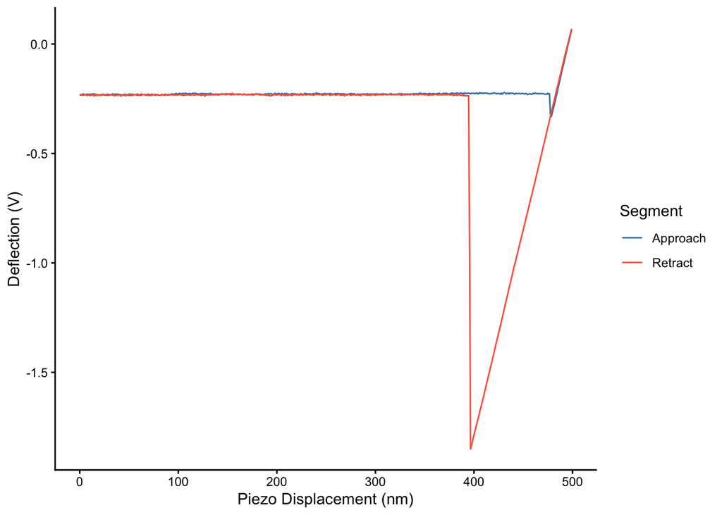

```r
print(ggplot(curve_df) +
  geom_line(aes(x = Calc_Ramp_Ex_nm, y = Defl_V_Ex, color = "Approach")) +
  geom_line(aes(x = Calc_Ramp_Rt_nm, y = Defl_V_Rt, color = "Retract")) +
  scale_color_manual(values = c("Approach" = "steelblue", "Retract" = "tomato")) +
  labs(x = "Piezo Displacement (nm)", y = "Deflection (V)", color = "Segment") +
  theme_classic())
```

## Load demo data

All examples below use the demo dataset provided in `extdata/` within the package. This folder contains approximately 100 raw curve files exported from Bruker NanoScope Analysis with both approach and retract segments included. To use your own dataset, pass the path to the directory containing the data to the `folder` argument. Users can increase `threads` to enable parallel processing when loading a large folder, for example, more than 10000 curves, which can substantially reduce computation time.

In this step, we initialize an fdObj by importing the demo data directory `extdata/` with `createFdObjFromFolder()`. An fdObj is the core data container in curvana. It stores atomic force microscopy (AFM) force-distance curve data, including raw curves, transformed data, associated metadata for downstream analysis, and the analytical metrics generated.

### Bruker/Veeco-style ASCII

Use `createFdObjFromFolder()` for generic Bruker/Veeco-style column-separated files. By default, the function reads all `.txt` files (or `.csv` if `suffix = ".csv"`) and removes lines starting with `#` or `"` before import. It expects at least one valid segment (approach or retract) with displacement and deflection columns. The default Bruker column names are `Calc_Ramp_Ex_nm`, `Defl_V_Ex`, `Calc_Ramp_Rt_nm`, and `Defl_V_Rt`, but these can be replaced with custom headers for other exports. If contact and non-interaction regions are in the opposite orientation, use the `reverse_*` arguments to correct direction. If users have only approach or retract data, they can still use this function to create an fdObj by specifying column names only for the available segment and leaving the arguments for the missing segment unchanged. The function will automatically ignore the missing segment and create an fdObj containing only the available data.

```r
folder = system.file("extdata", package = "curvana")
test.input = createFdObjFromFolder(folder = folder,
                                  Displacement_Approach = "Calc_Ramp_Ex_nm", # column name for piezo displacement in the approach curve
                                  Deflection_Approach = "Defl_V_Ex", # column name for cantilever deflection in the approach curve
                                  Displacement_Retract = "Calc_Ramp_Rt_nm", # column name for piezo displacement in the retract curve
                                  Deflection_Retract = "Defl_V_Rt", # column name for cantilever deflection in the retract curve
                                  reverse_Displacement_Approach = FALSE, # set to FALSE to keep the piezo displacement column for the approach curve as is
                                  reverse_Displacement_Retract = TRUE, # set to TRUE to reverse the piezo displacement column for the retract curve
                                  reverse_Deflection_Approach = TRUE, # set to TRUE to reverse the cantilever deflection column for the approach curve
                                  reverse_Deflection_Retract = FALSE # set to FALSE to keep the cantilever deflection column for the retract curve as is
                                  )
```

### JPK-style ASCII

For JPK ASCII exports, use the dedicated importer `createFdObjFromJPKFolder()` instead of `createFdObjFromFolder()`. The JPK importer automatically detects approach/retract segments, parses spring constant and sensitivity, and converts force data back to Voltage when needed. Users are encouraged to directly import raw deflection voltage in analysis.

Specifically, `createFdObjFromJPKFolder()`:

- Detects approach and retract segments automatically
- Parses sensitivity and spring constant for each segment; if deflection is in force units (N), converts it back to voltage
- Converts distance to nm, applies optional segment reversal, and records imported parameters plus datapoint counts in metadata

```r
# For JPK ASCII data, use the JPK-specific importer:
jpk_folder <- system.file("extdata_jpk", package = "curvana")

test.input.jpk <- createFdObjFromJPKFolder(
  folder = jpk_folder,
  height_col = "height",
  deflection_col = "vDeflection"
)
```

```r
print(test.input)
```

```
## An object of class "fdObj"
## ----------------------------------------
## Samples registered:  101
## Raw curves imported:  101
## Transformed approach curves:  0
## Transformed retract curves:   0
##
## Metadata columns:
##   - filename
##   - Number_of_datapoints_approach
##   - Number_of_datapoints_retract
```

```r
view_df(test.input@metadata,'metadata')
```

|  | filename | Number_of_datapoints_approach | Number_of_datapoints_retract |
| --- | --- | --- | --- |
| F_1.spm-F4E1_ForceCurveIndex_0.spm | F_1.spm-F4E1_ForceCurveIndex_0.spm | 512 | 512 |
| F_1.spm-F4E1_ForceCurveIndex_1.spm | F_1.spm-F4E1_ForceCurveIndex_1.spm | 512 | 512 |
| F_1.spm-F4E1_ForceCurveIndex_10.spm | F_1.spm-F4E1_ForceCurveIndex_10.spm | 512 | 512 |
| F_1.spm-F4E1_ForceCurveIndex_2.spm | F_1.spm-F4E1_ForceCurveIndex_2.spm | 512 | 512 |
| F_1.spm-F4E1_ForceCurveIndex_3.spm | F_1.spm-F4E1_ForceCurveIndex_3.spm | 512 | 512 |
| F_1.spm-F4E1_ForceCurveIndex_4.spm | F_1.spm-F4E1_ForceCurveIndex_4.spm | 512 | 512 |
| F_1.spm-F4E1_ForceCurveIndex_5.spm | F_1.spm-F4E1_ForceCurveIndex_5.spm | 512 | 512 |
| F_1.spm-F4E1_ForceCurveIndex_6.spm | F_1.spm-F4E1_ForceCurveIndex_6.spm | 512 | 512 |
| F_1.spm-F4E1_ForceCurveIndex_7.spm | F_1.spm-F4E1_ForceCurveIndex_7.spm | 512 | 512 |
| F_1.spm-F4E1_ForceCurveIndex_8.spm | F_1.spm-F4E1_ForceCurveIndex_8.spm | 512 | 512 |

[output cut: 91 more lines]

## Manipulate the fdObj object

The demo dataset contains measurements made on different surfaces and at different regions. Let’s group them in the metadata.

```r
test <- test.input
test@metadata <- test@metadata %>%
  mutate(surface = sub("_.*","",filename),
         surface = case_when(
            surface == 'F' ~ 'Group_A',
            surface == 'P' ~ 'Group_B',
            surface == 'silicon' ~ 'Group_C',
            surface == 'Z' ~ 'Group_D',
            TRUE ~ surface),
         region = sub(".*?_([0-9]+)\\.spm.*", "\\1", filename)
  )
view_df(test@metadata,'metadata')
```

|  | filename | Number_of_datapoints_approach | Number_of_datapoints_retract | surface | region |
| --- | --- | --- | --- | --- | --- |
| F_1.spm-F4E1_ForceCurveIndex_0.spm | F_1.spm-F4E1_ForceCurveIndex_0.spm | 512 | 512 | Group_A | 1 |
| F_1.spm-F4E1_ForceCurveIndex_1.spm | F_1.spm-F4E1_ForceCurveIndex_1.spm | 512 | 512 | Group_A | 1 |
| F_1.spm-F4E1_ForceCurveIndex_10.spm | F_1.spm-F4E1_ForceCurveIndex_10.spm | 512 | 512 | Group_A | 1 |
| F_1.spm-F4E1_ForceCurveIndex_2.spm | F_1.spm-F4E1_ForceCurveIndex_2.spm | 512 | 512 | Group_A | 1 |
| F_1.spm-F4E1_ForceCurveIndex_3.spm | F_1.spm-F4E1_ForceCurveIndex_3.spm | 512 | 512 | Group_A | 1 |
| F_1.spm-F4E1_ForceCurveIndex_4.spm | F_1.spm-F4E1_ForceCurveIndex_4.spm | 512 | 512 | Group_A | 1 |
| F_1.spm-F4E1_ForceCurveIndex_5.spm | F_1.spm-F4E1_ForceCurveIndex_5.spm | 512 | 512 | Group_A | 1 |
| F_1.spm-F4E1_ForceCurveIndex_6.spm | F_1.spm-F4E1_ForceCurveIndex_6.spm | 512 | 512 | Group_A | 1 |
| F_1.spm-F4E1_ForceCurveIndex_7.spm | F_1.spm-F4E1_ForceCurveIndex_7.spm | 512 | 512 | Group_A | 1 |
| F_1.spm-F4E1_ForceCurveIndex_8.spm | F_1.spm-F4E1_ForceCurveIndex_8.spm | 512 | 512 | Group_A | 1 |

[output cut: 91 more lines]

```r
test_beforeTransform <- test
```

It is also possible to extract specific samples from an fdObj either by providing their sample names, that is, row names in the metadata, or by subsetting the object based on conditions applied to metadata columns.

```r
test.group_b = extract(test,by_col = list(surface = "Group_B"))
test.group_c = extract(test,by_sample = rownames(test@metadata[test@metadata$surface == 'Group_C',]))
```

Just as we might need to subset an fdObj, we might also need to combine two fdObjs, for example, from different experiments. The `combineFdObj()` function is designed for this purpose. If there are overlapping samples between the two fdObjs being combined, `combineFdObj()` will return an error.

```r
test.combine.1 = combineFdObj(test.group_b,test.group_c)
#test.combine.2 = combineFdObj(test.paeru,test.paeru2) # should return error
```

# Preview the raw deflection curves

## Deflection vs data point index

Here we use `plot_deflection_curves_by_index()` to plot raw deflection values against the row index (data point number) for each curve. This visualization helps us: - See how many data points are in each curve - Verify that the data is oriented in the correct direction (contact region at the beginning, non-interaction region at the end) - Help us with selecting the appropriate regions for baseline calibration and sensitivity calculation in the next step.

We split curves into subpanels by `surface` and color-code them by `region`.

```
## 101 samples in the input; 101 approach and 101 retract curves are plotted.
```

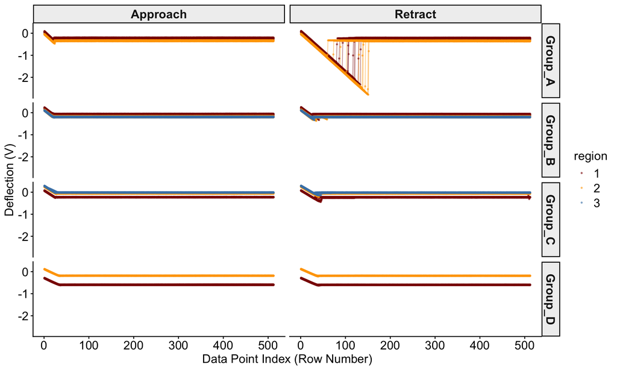

```r
plot_deflection_curves_by_index(test,split_curves_by = 'surface',group_curves_by = 'region',
                       alpha = 0.5,point_size = 0.5,
                       color_map = list(`1` = 'darkred',
                                        `2` = 'orange',
                                        `3` = 'steelblue'))
```

## Scatter plot of deflection curves

We can use `plot_deflection_curves()` to plot curves in batch. Here, we split curves into subpanels by `surface` and color-code them by `region`.

```
## 101 samples in the input; 101 approach and 101 retract curves are plotted.
```

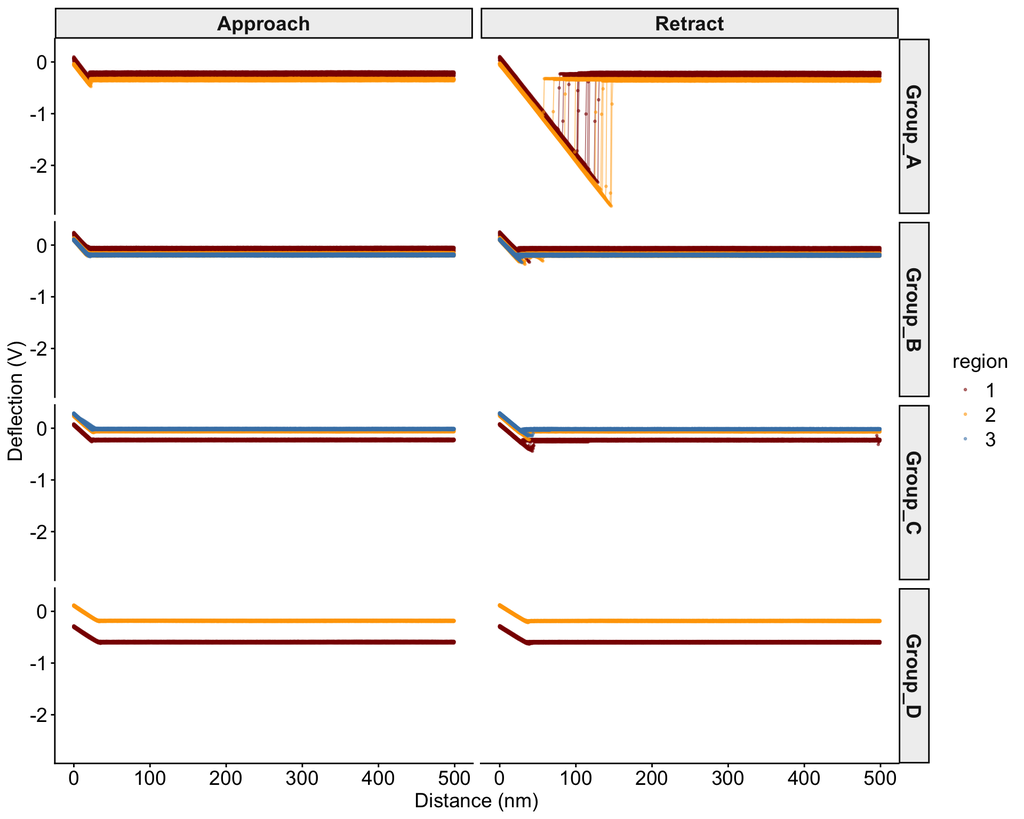

```r
plot_deflection_curves(test,split_curves_by = 'surface',group_curves_by = 'region',
                       alpha = 0.5,point_size = 0.5,
                       color_map = list(`1` = 'darkred',
                                        `2` = 'orange',
                                        `3` = 'steelblue'))
```

# Curve transformation

One advantage of curvana is that each step of the data analysis is modularized, enabling a flexible and customizable workflow. Curve transformation in curvana involves several steps, including denoising, sensitivity calculation, baseline offset calculation, and application of these parameters to convert raw data into interaction force-separation distance curves.

## Single curve transformation

### Denoising

To demonstrate how an individual curve is transformed, we use a raw retract curve as an example. First, we apply `denoise_a_curve()` to the raw curve. The function internally applies a Savitzky-Golay filter to smooth the curve, which can help reduce noise and improve the reliability of sensitivity and baseline calculations. The smoothed curve is used for downstream analysis, while the original raw curve is preserved in the `rawCurves` slot of the object for reference.

Here we set the polynomial order `p` to 1 and the window size `n` to 3 for the Savitzky-Golay filter. This means the function fits a linear polynomial to each window of 3 points to smooth the curve, which is equivalent to a simple moving average. Users can adjust these parameters based on the noise level and characteristics of their curves.

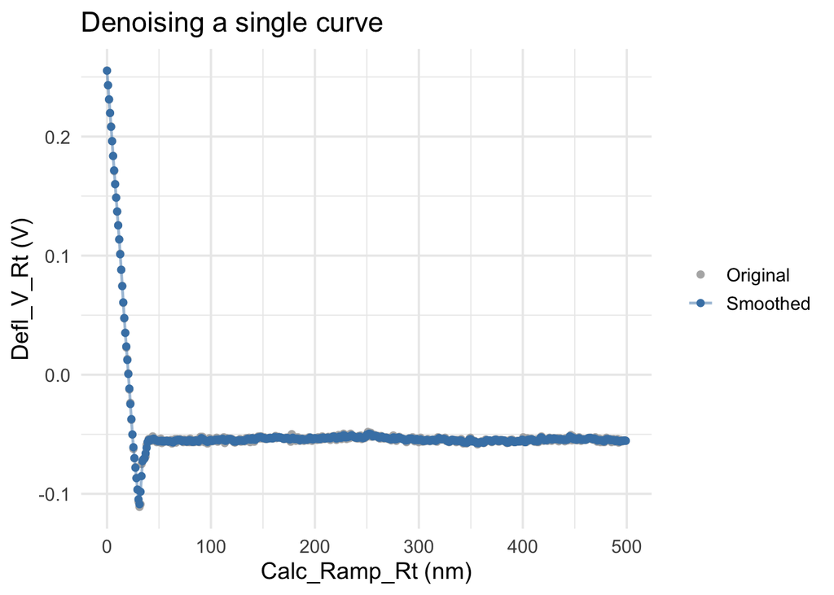

```r
example1.name = 'silicon_wafer_2.spm-2658_ForceCurveIndex_1.spm'
example1.raw = test_beforeTransform@rawCurves[[example1.name]]
example1.raw = denoise_a_curve(example1.raw, useCurve = "retract", p = 1, n = 3)

ggplot(data = example1.raw) +
  geom_point(aes(x = Calc_Ramp_Rt_nm, y = Defl_V_Rt_original, color = "Original"), size = 1.5) +
  geom_point(aes(x = Calc_Ramp_Rt_nm, y = Defl_V_Rt, color = "Smoothed"), size = 1.5) +
  geom_path(aes(x = Calc_Ramp_Rt_nm, y = Defl_V_Rt, color = "Smoothed"), size = 0.8,alpha=0.5) +
  scale_color_manual(values = c("Original" = "grey70", "Smoothed" = "steelblue")) +
  labs(x = "Calc_Ramp_Rt (nm)", y = "Defl_V_Rt (V)", title = "Denoising a single curve") +
  theme_minimal(base_size = 14) +
  theme(legend.title=element_blank())
```

To denoise all curves in the object at once, we can run `denoise_curves()`. The function internally executes `denoise_a_curve()` for each curve separately and saves the smoothed curve in the `rawCurves` slot of the object. The original, unsmoothed curve is moved to the `Defl_V_<useCurve>_original` column. Users can specify the smoothing method and parameters, or choose to skip smoothing if desired.

```r
test2 = denoise_curves(test_beforeTransform,useCurve = 'approach',p = 1, n = 3)
```

```
## Denoised 101 raw curves (useCurve = 'approach').
```

```r
test2 = denoise_curves(test2,useCurve = 'retract',p = 1, n = 3)
```

```
## Denoised 101 raw curves (useCurve = 'retract').
```

### Sensitivity calculation

The function `calc_sensitivity()` is designed to calculate the sensitivity value automatically. It returns two outputs: the sensitivity value and the subset of data points used to calculate it. The second element of the returned list is a named data frame called `senscal_segment`.

For sensitivity calculation, the function automatically identifies the linear region in the leftmost part of the curve up to the data point specified by the `end` argument. It iteratively builds a segment by adding data points from left to right and performs linear regression on the segment at each step. The iteration continues until the $R^2$ value of the linear regression drops below the user-defined threshold `R_squared_min` or reaches the user-defined maximum length `end`. The slope of the final segment is then recorded as the sensitivity value for that curve. Users can also set a minimum accepted segment length `minimum_length` to ensure reliable sensitivity estimation.

Here, we set `end = 20` to use only the first 20 points of the curve for sensitivity calculation, and `R_squared_min = 0.99` to ensure that the selected segment is highly linear. We also set `minimum_length = 4`, meaning that if the final selected segment has fewer than 4 points, the sensitivity calculation is considered to have failed and the function returns `NA`.

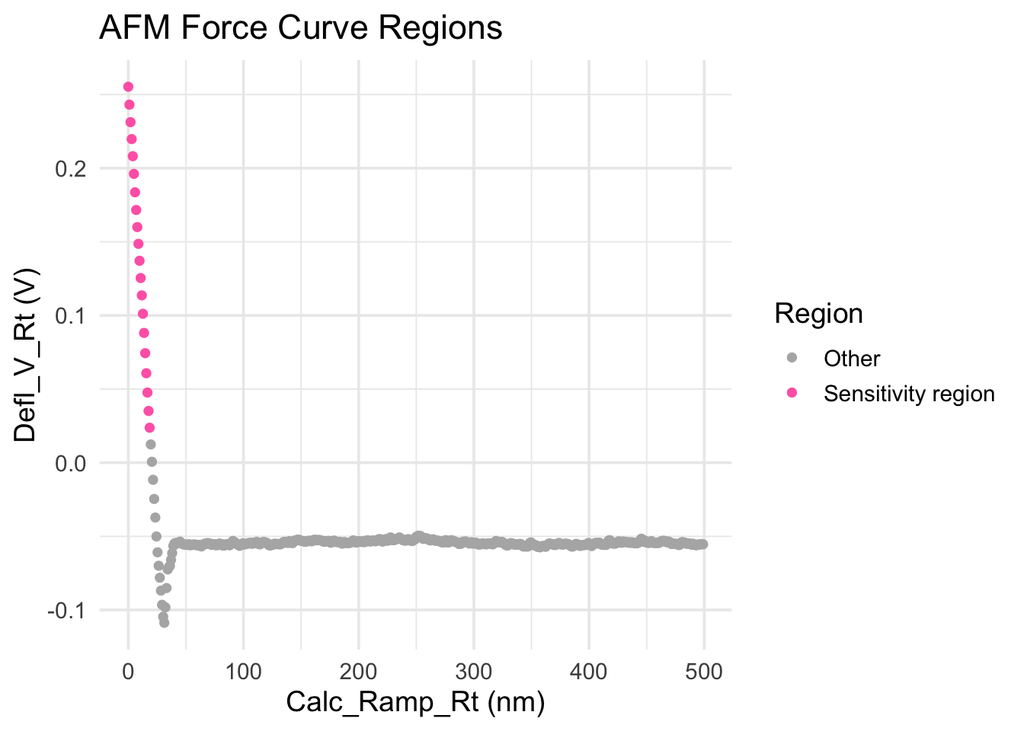

```r
x = example1.raw$Calc_Ramp_Rt_nm
y = example1.raw$Defl_V_Rt
res.sens = calc_sensitivity(end = 20, x = x, y = y, R_squared_min = 0.99, minimum_length = 4)
example1.raw$`Region used for Sensitivity calculation` = case_when(example1.raw$Calc_Ramp_Rt_nm %in% res.sens$senscal_segment$x ~ "Sensitivity region", TRUE ~ "Other")

ggplot(example1.raw, aes(x = Calc_Ramp_Rt_nm, y = Defl_V_Rt)) +
  geom_point(aes(
    color = `Region used for Sensitivity calculation`  ), size = 1.5) +
  scale_color_manual(
    values = c(
      "Sensitivity region" = "hotpink",
      "Other" = "grey70"
    ),
    name = "Region"
  ) +
  labs(
    x = "Calc_Ramp_Rt (nm)",
    y = "Defl_V_Rt (V)",
    title = "AFM Force Curve Regions"
  ) +
  theme_minimal(base_size = 14)
```

To analyze sensitivity values for all curves in the object at once, we can run `analyze_sensitivity()`. The function internally executes `calc_sensitivity()` for each curve separately and records the sensitivity value of each curve in a metadata column named `sensitivity_V_nm_dir`, where `dir` is the selected curve portion specified by the `useCurve` argument, either `approach` or `retract`.

Curves that fail sensitivity calculation will have `NA` in their corresponding cells. The segment of each raw curve used for sensitivity calculation is saved in the object’s `senscal_segment` slot.

```r
test2 = analyze_sensitivity(test2,useCurve = 'approach',end = 20)
```

```
## Processed 101 curves; 0 failed sensitivity calculation.
```

```r
test2 = analyze_sensitivity(test2,useCurve = 'retract',end = 20)
```

```
## Processed 101 curves; 0 failed sensitivity calculation.
```

```r
view_df(test2@metadata,'metadata with sensitivity values added as columns')
```

|  | filename | Number_of_datapoints_approach | Number_of_datapoints_retract | surface | region | sensitivity_V_nm_approach | sensitivity_V_nm_retract |
| --- | --- | --- | --- | --- | --- | --- | --- |
| F_1.spm-F4E1_ForceCurveIndex_0.spm | F_1.spm-F4E1_ForceCurveIndex_0.spm | 512 | 512 | Group_A | 1 | 0.01953175268173134 | 0.0185355755023641 |
| F_1.spm-F4E1_ForceCurveIndex_1.spm | F_1.spm-F4E1_ForceCurveIndex_1.spm | 512 | 512 | Group_A | 1 | 0.01919879781109477 | 0.01851595098597184 |
| F_1.spm-F4E1_ForceCurveIndex_10.spm | F_1.spm-F4E1_ForceCurveIndex_10.spm | 512 | 512 | Group_A | 1 | 0.01938341015922519 | 0.01848164144586605 |
| F_1.spm-F4E1_ForceCurveIndex_2.spm | F_1.spm-F4E1_ForceCurveIndex_2.spm | 512 | 512 | Group_A | 1 | 0.0184777721502696 | 0.01877256318423071 |
| F_1.spm-F4E1_ForceCurveIndex_3.spm | F_1.spm-F4E1_ForceCurveIndex_3.spm | 512 | 512 | Group_A | 1 | 0.01864995710405837 | 0.01876507451418484 |
| F_1.spm-F4E1_ForceCurveIndex_4.spm | F_1.spm-F4E1_ForceCurveIndex_4.spm | 512 | 512 | Group_A | 1 | 0.01958435316127593 | 0.01860802118930836 |
| F_1.spm-F4E1_ForceCurveIndex_5.spm | F_1.spm-F4E1_ForceCurveIndex_5.spm | 512 | 512 | Group_A | 1 | 0.01974969378924028 | 0.01855071135453553 |
| F_1.spm-F4E1_ForceCurveIndex_6.spm | F_1.spm-F4E1_ForceCurveIndex_6.spm | 512 | 512 | Group_A | 1 | 0.0190822422605573 | 0.01838381145447972 |
| F_1.spm-F4E1_ForceCurveIndex_7.spm | F_1.spm-F4E1_ForceCurveIndex_7.spm | 512 | 512 | Group_A | 1 | 0.01926291314275661 | 0.01838945375728929 |
| F_1.spm-F4E1_ForceCurveIndex_8.spm | F_1.spm-F4E1_ForceCurveIndex_8.spm | 512 | 512 | Group_A | 1 | 0.01846043987251427 | 0.01815902925417498 |

[output cut: 91 more lines]

### Baseline offsets

Like `calc_sensitivity()`, `find_baseline()` returns two outputs: the offset value and the subset of data points used to calculate it.

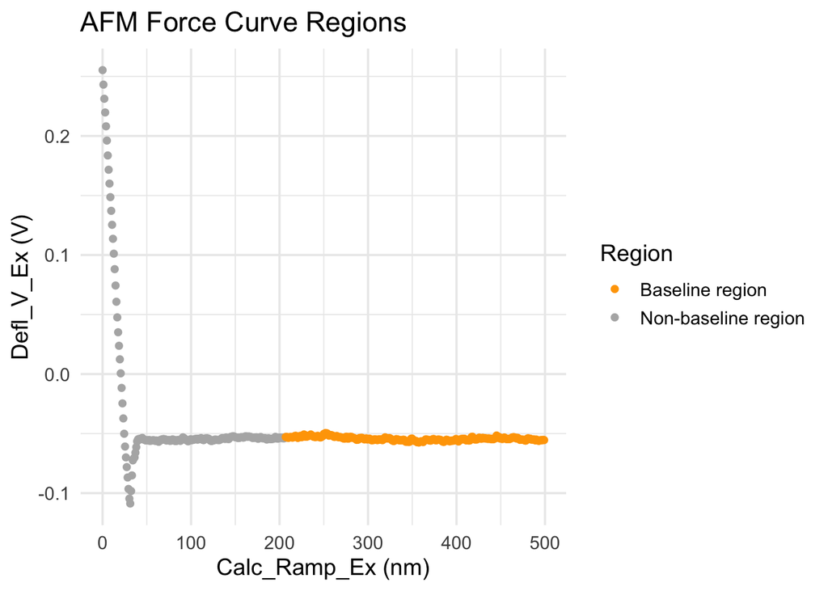

```r
res.base = find_baseline(x = x, y = y,  sensitivity = res.sens$sensitivity, spring_constant = 0.08, least_length = 300,slp_threshold = 0.01,std_threshold = 0.01)
example1.raw$`Region used for baseline offset calculation` = case_when(example1.raw$Calc_Ramp_Rt_nm %in% res.base$segment$x ~ "Baseline region", TRUE ~ "Non-baseline region")

ggplot(example1.raw, aes(x = Calc_Ramp_Rt_nm, y = Defl_V_Rt)) +
  geom_point(aes(color = `Region used for baseline offset calculation`), size = 1.5) +
  scale_color_manual(
    values = c(
      "Baseline region" = "orange",
      "Non-baseline region" = "grey70"
    ),
    name = "Region"
  ) +
  labs(
    x = "Calc_Ramp_Ex (nm)",
    y = "Defl_V_Ex (V)",
    title = "AFM Force Curve Regions"
  ) +
  theme_minimal(base_size = 14)
```

To analyze the baseline offset for all curves in an fdObj at once, we use `analyze_baseline()`. This function internally calls `find_baseline()` for each curve and records the computed baseline offset values in the metadata columns `baseline_V_dir`, along with the user-defined length of the baseline segment. The spring constant can be supplied as a numeric value or as the name of a metadata column. The portion of each raw curve used for baseline offset estimation is stored in the object’s `baseline_segment` slot.

Curves can exhibit undulating or unstable baselines. Such abnormal curves, identified by a slope greater than `slp_threshold` and a standard deviation greater than `std_threshold`, are considered unreliable and are omitted from subsequent analyses. Curves that fail baseline calculation are assigned `NA` in these metadata columns. `analyze_baseline()` automatically looks up the sensitivity columns generated by `analyze_sensitivity()`. Since baseline estimation requires a valid sensitivity value, any curve that fails sensitivity calculation, that is, does not have a numeric sensitivity value in the corresponding metadata column, will also fail baseline calculation.

```r
test2 = analyze_baseline(test2,useCurve = 'approach',least_length = 300,spring_constant = 0.08,slp_threshold = 0.01,std_threshold = 0.01)
```

```
## Processed 101 curves; 7 failed baseline detection.
```

```r
test2 = analyze_baseline(test2,useCurve = 'retract', least_length = 300,spring_constant = 0.08,slp_threshold = 0.01,std_threshold = 0.01)
```

```
## Processed 101 curves; 9 failed baseline detection.
```

```r
view_df(test2@metadata,'metadata with baseline values added as columns')
```

|  | filename | Number_of_datapoints_approach | Number_of_datapoints_retract | surface | region | sensitivity_V_nm_approach | sensitivity_V_nm_retract | baseline_V_approach | baseline_span_approach | baseline_V_retract | baseline_span_retract |
| --- | --- | --- | --- | --- | --- | --- | --- | --- | --- | --- | --- |
| F_1.spm-F4E1_ForceCurveIndex_0.spm | F_1.spm-F4E1_ForceCurveIndex_0.spm | 512 | 512 | Group_A | 1 | 0.01953175268173134 | 0.0185355755023641 | -0.22915625 | 300 | -0.2324710416666667 | 300 |
| F_1.spm-F4E1_ForceCurveIndex_1.spm | F_1.spm-F4E1_ForceCurveIndex_1.spm | 512 | 512 | Group_A | 1 | 0.01919879781109477 | 0.01851595098597184 | -0.2264658333333334 | 300 | -0.2322664583333333 | 300 |
| F_1.spm-F4E1_ForceCurveIndex_10.spm | F_1.spm-F4E1_ForceCurveIndex_10.spm | 512 | 512 | Group_A | 1 | 0.01938341015922519 | 0.01848164144586605 | -0.2568625 | 300 | -0.261550625 | 300 |
| F_1.spm-F4E1_ForceCurveIndex_2.spm | F_1.spm-F4E1_ForceCurveIndex_2.spm | 512 | 512 | Group_A | 1 | 0.0184777721502696 | 0.01877256318423071 | -0.2240177083333333 | 300 | -0.2283635416666667 | 300 |
| F_1.spm-F4E1_ForceCurveIndex_3.spm | F_1.spm-F4E1_ForceCurveIndex_3.spm | 512 | 512 | Group_A | 1 | 0.01864995710405837 | 0.01876507451418484 | -0.2190122916666667 | 300 | -0.2244814583333334 | 300 |
| F_1.spm-F4E1_ForceCurveIndex_4.spm | F_1.spm-F4E1_ForceCurveIndex_4.spm | 512 | 512 | Group_A | 1 | 0.01958435316127593 | 0.01860802118930836 | -0.2118975 | 300 | -0.2193322916666667 | 300 |
| F_1.spm-F4E1_ForceCurveIndex_5.spm | F_1.spm-F4E1_ForceCurveIndex_5.spm | 512 | 512 | Group_A | 1 | 0.01974969378924028 | 0.01855071135453553 | -0.208544375 | 300 | -0.2122558333333334 | 300 |
| F_1.spm-F4E1_ForceCurveIndex_6.spm | F_1.spm-F4E1_ForceCurveIndex_6.spm | 512 | 512 | Group_A | 1 | 0.0190822422605573 | 0.01838381145447972 | -0.2024758333333334 | 300 | -0.2084514583333334 | 300 |
| F_1.spm-F4E1_ForceCurveIndex_7.spm | F_1.spm-F4E1_ForceCurveIndex_7.spm | 512 | 512 | Group_A | 1 | 0.01926291314275661 | 0.01838945375728929 | -0.1937797916666667 | 300 | -0.201685625 | 300 |
| F_1.spm-F4E1_ForceCurveIndex_8.spm | F_1.spm-F4E1_ForceCurveIndex_8.spm | 512 | 512 | Group_A | 1 | 0.01846043987251427 | 0.01815902925417498 | -0.2695852083333334 | 300 | -0.2802514583333334 | 300 |

[output cut: 91 more lines]

## Transformation of a raw curve

Now that the sensitivity and baseline offset values have been calculated, we are ready to transform the curve with `transform_a_curve()`. `senscal_seg_x` and `senscal_seg_y` are the x and y values of the segment used for sensitivity calculation, and they are also used for curve transformation.

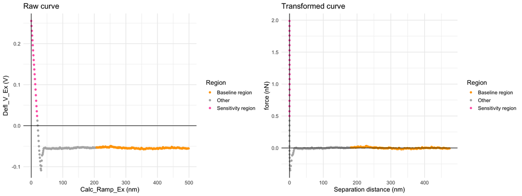

```r
example1.transformed = transform_a_curve(x = x, y= y, baseline = res.base$baseline, sensitivity = res.sens$sensitivity,
                             spring_constant = 0.08, senscal_seg_x = res.sens$senscal_segment$x,
                             senscal_seg_y = res.sens$senscal_segment$y)

p1 = ggplot(example1.raw, aes(x = Calc_Ramp_Rt_nm, y = Defl_V_Rt)) +
  geom_point(aes(
    color = case_when(
      `Region used for Sensitivity calculation` == 'Sensitivity region' ~ "Sensitivity region",
      `Region used for baseline offset calculation` == 'Baseline region' ~ "Baseline region",
      TRUE ~ "Other"
    )
  ), size = 1.5) +
  scale_color_manual(
    values = c(
      "Sensitivity region" = "hotpink",
      "Baseline region" = "orange",
      "Other" = "grey70"
    ),
    name = "Region"
  ) +
  labs(
    x = "Calc_Ramp_Ex (nm)",
    y = "Defl_V_Ex (V)",
    title = "Raw curve"
  ) +
  theme_minimal(base_size = 14) +
  geom_hline(yintercept = 0, color = "black", linewidth = 0.5) +
  geom_vline(xintercept = 0, color = "black", linewidth = 0.5)


example1.transformed = cbind(example1.transformed, example1.raw[,c('Region used for Sensitivity calculation','Region used for baseline offset calculation')])
p2 = ggplot(example1.transformed, aes(x = separation_distance_nm, y = force_nN)) +
  geom_point(aes(
    color = case_when(
      `Region used for Sensitivity calculation` == "Sensitivity region" ~ "Sensitivity region",
      `Region used for baseline offset calculation` == "Baseline region" ~ "Baseline region",
      TRUE ~ "Other"
    )
  ), size = 1.5) +
  scale_color_manual(
    values = c(
      "Sensitivity region" = "hotpink",
      "Baseline region" = "orange",
      "Other" = "grey70"
    ),
    name = "Region"
  ) +
  labs(
    x = "Separation distance (nm)",
    y = "force (nN)",
    title = "Transformed curve"
  ) +
  theme_minimal(base_size = 14) +
  geom_hline(yintercept = 0, color = "black", linewidth = 0.5) +
  geom_vline(xintercept = 0, color = "black", linewidth = 0.5)

plot_grid(p1,p2)
```

## Transform curves using the wrapper function `transform_curves()`

At this step, we apply the wrapper function `transform_curves()` to transform all raw curves in the fdObj into calibrated force-distance curves at once. This function streamlines the entire transformation process by internally calling `denoise_curves()`, `analyze_sensitivity()`, and `analyze_baseline()` to denoise raw curves and estimate sensitivity and baseline values. All arguments accepted by these individual functions can be passed directly to `transform_curves()`, allowing full control over the analysis parameters.

**Note: If the sensitivity and baseline columns already exist in the metadata, the function skips the calculation step and directly uses the existing values for curve transformation. To rerun the calculation, you can remove the existing columns from the metadata.**

To transform a curve, the spring constant of the AFM probe is required to convert deflection (V) to force (nN). `transform_curves()` accepts either a single numeric value, applied to all curves and stored in `metadata$spring_constant`, or a metadata column name containing per-curve spring constants. These values are then used with the computed baseline and sensitivity to generate the final force-distance curves.

```r
test = transform_curves(test_beforeTransform,
                        denoise_first = TRUE, # whether to denoise raw curves before transformation. Denoising can improve the reliability of sensitivity and baseline calculations, especially for noisy curves. The smoothed curve will be used for downstream analysis, while the original raw curve will be preserved in the rawCurves slot for reference.
                        p = 1, n = 3, # parameters for the Savitzky-Golay filter used for denoising. p is the polynomial order (default 1, meaning linear), and n is the window size (default 3, meaning each point is smoothed by fitting a polynomial to itself and its 2 neighbors). Users can adjust these parameters based on curve noise and shape.

                        spring_constant = 0.08, # spring constant
                        useCurve = 'approach', # analyze the approach curve

                        # baseline determination and filtering
                        least_length = 300, # use the last 300 points as baseline
                        slp_threshold = 0.01, # any curve with a baseline-region slope > 0.01 will be discarded
                        std_threshold = 0.01, # any curve with a baseline-region standard deviation of y values > 0.01 will be discarded

                        # sensitivity calibration
                        intv = 4, # number of data points added per iteration when building the linear sensitivity segment
                        end = 20, # use at most the first 20 data points on the left side of the curve to calibrate sensitivity
                        R_squared_min = 0.99, # minimum R^2 threshold for accepting a segment as sufficiently linear during sensitivity calculation
                        minimum_length = 4 # minimum number of accumulated points required for a valid sensitivity result; if shorter, sensitivity is reported as NA
                        )
```

```
## Denoised 101 raw curves (useCurve = 'approach').
```

```
## Using fixed spring constant: 0.0800 nN/nm (stored in metadata$spring_constant).
```

```
## Column 'sensitivity_V_nm_approach' not found in metadata. Running analyze_sensitivity()...
```

```
## Processed 101 curves; 0 failed sensitivity calculation.
```

```
## Column 'baseline_V_approach' not found in metadata. Running analyze_baseline()...
```

```
## Processed 101 curves; 7 failed baseline detection.
```

```
## Processed 101 curves (approach); 7 failed transformation.
```

```r
test = transform_curves(test,
                        denoise_first = TRUE,
                        p = 1, n = 3,
                        spring_constant = 0.08,
                        useCurve = 'retract', # analyze the retract curve

                        # baseline determination and filtering
                        least_length = 300,
                        slp_threshold = 0.01,
                        std_threshold = 0.01,

                        # sensitivity calibration
                        intv = 4,
                        end = 20,
                        R_squared_min = 0.99,
                        minimum_length = 4)
```

```
## Denoised 101 raw curves (useCurve = 'retract').
```

```
## Using fixed spring constant: 0.0800 nN/nm (stored in metadata$spring_constant).
```

```
## Column 'sensitivity_V_nm_retract' not found in metadata. Running analyze_sensitivity()...
```

```
## Processed 101 curves; 0 failed sensitivity calculation.
```

```
## Column 'baseline_V_retract' not found in metadata. Running analyze_baseline()...
```

```
## Processed 101 curves; 9 failed baseline detection.
```

```
## Processed 101 curves (retract); 9 failed transformation.
```

## Soft surface correction

**When measuring on a compliant (soft) surface, such as a hydrogel, cell membrane, or polymer brush, the contact region of the curve reflects a combined response from both cantilever deflection and surface indentation. Using this region to estimate probe sensitivity will therefore underestimate the true probe sensitivity. To correct for this, the probe sensitivity should be calibrated separately on a rigid reference surface (for example, bare glass or silicon) and then supplied to `transform_curves()` when processing soft-surface curves.**

**To do this, set `soft = TRUE` and provide the externally calibrated sensitivity via `probe_sensitivity_external`. This can be either a single numeric value, applied to all curves, or the name of a metadata column containing per-curve sensitivity values. When `soft = TRUE`, `transform_curves()` uses this external sensitivity to convert deflection (V) to force (nN). Note that the x-axis transformation, from piezo displacement to separation distance, is unaffected and always uses the sensitivity estimated from each individual curve, preserving the deformation component in the separation distance.**

```r
test3 = transform_curves(test,
                        useCurve = 'retract', # analyze the retract curve
                        denoise_first = TRUE,
                        p = 1, n = 3,
                        spring_constant = 0.08,
                        # baseline determination and filtering
                        least_length = 300,
                        std_threshold = 0.01,
                        slp_threshold = 0.01,
                        # sensitivity calibration
                        intv = 4,
                        end = 20,
                        R_squared_min = 0.99,
                        minimum_length = 4,
                        # soft surface correction
                        soft = TRUE, # whether to apply soft surface correction
                        probe_sensitivity_external = 0.05 # externally calibrated sensitivity value to use for soft surface correction (in V/nm). This can be a single numeric value applied to all curves, or the name of a metadata column containing per-curve sensitivity values.
                        )
```

```
## Using fixed probe sensitivity: 0.05 (stored in metadata$probe_true_sensitivity_V_nm_retract).
```

```
## Denoised 101 raw curves (useCurve = 'retract').
```

```
## Using fixed spring constant: 0.0800 nN/nm (stored in metadata$spring_constant).
```

```
## Processed 101 curves (retract); 9 failed transformation.
```

## Examine the object after transformation

We can see that the curves have now been transformed.

```r
print(test)
```

```
## An object of class "fdObj"
## ----------------------------------------
## Samples registered:  101
## Raw curves imported:  101
## Transformed approach curves:  94
## Transformed retract curves:   92
##
## Metadata columns:
##   - filename
##   - Number_of_datapoints_approach
##   - Number_of_datapoints_retract
##   - surface
##   - region
##   - spring_constant
##   - sensitivity_V_nm_approach
##   - baseline_V_approach
##   - baseline_span_approach
##   - sensitivity_V_nm_retract
##   - baseline_V_retract
##   - baseline_span_retract
```

The transformed curves are stored in the `retractCurves` and `approachCurves` slots of the fdObj. Note that when sensitivity or baseline cannot be reliably determined, such as in curves with highly fluctuating probe-surface contact regions or irregular baseline segments, the transformation will fail. In these cases, the corresponding entry in the transformed curve slot, `retractCurves` or `approachCurves`, is stored as an empty data frame with zero rows, indicating an unsuccessful transformation.

```r
print(names(test@retractCurves)%>% head())
```

```
## [1] "F_1.spm-F4E1_ForceCurveIndex_0.spm"  "F_1.spm-F4E1_ForceCurveIndex_1.spm"
## [3] "F_1.spm-F4E1_ForceCurveIndex_10.spm" "F_1.spm-F4E1_ForceCurveIndex_2.spm"
## [5] "F_1.spm-F4E1_ForceCurveIndex_3.spm"  "F_1.spm-F4E1_ForceCurveIndex_4.spm"
```

```r
print(names(test@approachCurves)%>% head())
```

```
## [1] "F_1.spm-F4E1_ForceCurveIndex_0.spm"  "F_1.spm-F4E1_ForceCurveIndex_1.spm"
## [3] "F_1.spm-F4E1_ForceCurveIndex_10.spm" "F_1.spm-F4E1_ForceCurveIndex_2.spm"
## [5] "F_1.spm-F4E1_ForceCurveIndex_3.spm"  "F_1.spm-F4E1_ForceCurveIndex_4.spm"
```

The calculated sensitivity, baseline, and input spring constant are now saved as columns in the metadata. Curves with undetermined baseline or sensitivity values will have missing values in the corresponding cells.

```r
view_df(test@metadata,'metadata after curve transformation')
```

|  | filename | Number_of_datapoints_approach | Number_of_datapoints_retract | surface | region | spring_constant | sensitivity_V_nm_approach | baseline_V_approach | baseline_span_approach | sensitivity_V_nm_retract | baseline_V_retract | baseline_span_retract |
| --- | --- | --- | --- | --- | --- | --- | --- | --- | --- | --- | --- | --- |
| F_1.spm-F4E1_ForceCurveIndex_0.spm | F_1.spm-F4E1_ForceCurveIndex_0.spm | 512 | 512 | Group_A | 1 | 0.08 | 0.01953175268173134 | -0.22915625 | 300 | 0.0185355755023641 | -0.2324710416666667 | 300 |
| F_1.spm-F4E1_ForceCurveIndex_1.spm | F_1.spm-F4E1_ForceCurveIndex_1.spm | 512 | 512 | Group_A | 1 | 0.08 | 0.01919879781109477 | -0.2264658333333334 | 300 | 0.01851595098597184 | -0.2322664583333333 | 300 |
| F_1.spm-F4E1_ForceCurveIndex_10.spm | F_1.spm-F4E1_ForceCurveIndex_10.spm | 512 | 512 | Group_A | 1 | 0.08 | 0.01938341015922519 | -0.2568625 | 300 | 0.01848164144586605 | -0.261550625 | 300 |
| F_1.spm-F4E1_ForceCurveIndex_2.spm | F_1.spm-F4E1_ForceCurveIndex_2.spm | 512 | 512 | Group_A | 1 | 0.08 | 0.0184777721502696 | -0.2240177083333333 | 300 | 0.01877256318423071 | -0.2283635416666667 | 300 |
| F_1.spm-F4E1_ForceCurveIndex_3.spm | F_1.spm-F4E1_ForceCurveIndex_3.spm | 512 | 512 | Group_A | 1 | 0.08 | 0.01864995710405837 | -0.2190122916666667 | 300 | 0.01876507451418484 | -0.2244814583333334 | 300 |
| F_1.spm-F4E1_ForceCurveIndex_4.spm | F_1.spm-F4E1_ForceCurveIndex_4.spm | 512 | 512 | Group_A | 1 | 0.08 | 0.01958435316127593 | -0.2118975 | 300 | 0.01860802118930836 | -0.2193322916666667 | 300 |
| F_1.spm-F4E1_ForceCurveIndex_5.spm | F_1.spm-F4E1_ForceCurveIndex_5.spm | 512 | 512 | Group_A | 1 | 0.08 | 0.01974969378924028 | -0.208544375 | 300 | 0.01855071135453553 | -0.2122558333333334 | 300 |
| F_1.spm-F4E1_ForceCurveIndex_6.spm | F_1.spm-F4E1_ForceCurveIndex_6.spm | 512 | 512 | Group_A | 1 | 0.08 | 0.0190822422605573 | -0.2024758333333334 | 300 | 0.01838381145447972 | -0.2084514583333334 | 300 |
| F_1.spm-F4E1_ForceCurveIndex_7.spm | F_1.spm-F4E1_ForceCurveIndex_7.spm | 512 | 512 | Group_A | 1 | 0.08 | 0.01926291314275661 | -0.1937797916666667 | 300 | 0.01838945375728929 | -0.201685625 | 300 |
| F_1.spm-F4E1_ForceCurveIndex_8.spm | F_1.spm-F4E1_ForceCurveIndex_8.spm | 512 | 512 | Group_A | 1 | 0.08 | 0.01846043987251427 | -0.2695852083333334 | 300 | 0.01815902925417498 | -0.2802514583333334 | 300 |

[output cut: 91 more lines]

## Plot transformed curves

To visualize the transformed curves, we can use `plot_fd_curves()`. Here, we plot the approach and retract curves in separate panels and color-code them by `region`.

```
## 101 samples in the input; 94 approach and 92 retract curves are plotted.
```

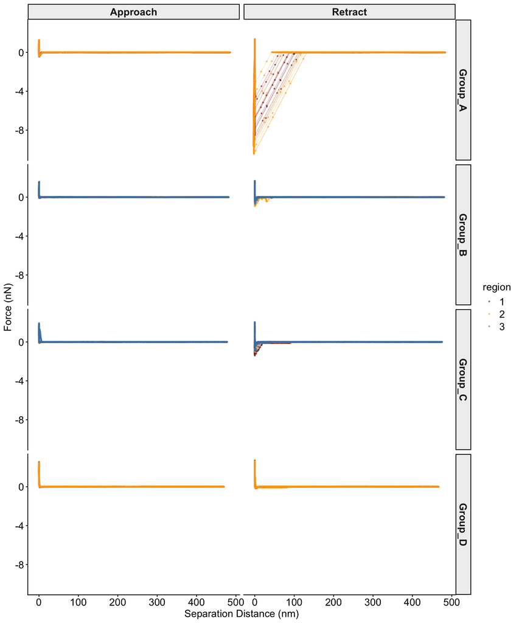

```r
plot_fd_curves(test,group_curves_by = 'region', split_curves_by = 'surface',
               point_alpha = 0.5,line_alpha = 0.3, point_size = 0.5,
               color_map = list(`1` = 'darkred',
                                `2` = 'orange',
                                `3` = 'steelblue'))
```

# Analytical metrics calculation

After curve transformation, we can calculate analytical metrics such as adhesive force, interaction energy, and interaction distance.

## Baseline noise-level determination

### Wrapper function for batch analysis

Before calculating analytical metrics, it is important to determine the baseline noise level so that insignificant fluctuations can be excluded from metric calculations. The function `analyze_a_curve_noise()` estimates lower and upper noise bands from baseline force values. For batch analysis, `analyze_curves_noise()` applies this to all transformed curves in an fdObj and writes the results into metadata columns `noiseBand_low_nN` and `noiseBand_high_nN`, one set for approach curves and one set for retract curves.

Supported noise-band determination methods are standard deviation (`sd`), median absolute deviation (`mad`), quantile (`quantile`), and fixed (`fixed`). The `multiplier` parameter scales the chosen noise metric to define the noise band. The noise bands are then reused in interaction-distance and interaction-energy analyses, so thresholds are determined once and applied consistently across curves.

Here we define the noise band as the range from the minimum to the maximum force in the baseline region.

**Note: Set the noise-band multiplier to 0 to disable noise-band thresholding.**

```r
test2 = analyze_curves_noise(test,
                            useCurve = 'approach', # calculate noise band for approach curves,
                            baseline_span = "automatic", # number of data points at the end of the curve to use as baseline region for noise level calculation. Here we set it to "automatic", which means the function will use the baseline_span column in the metadata.
                            threshold_method = 'quantile', # method to determine noise band. Here we use quantile, which means the noise band will be defined by the quantiles of the baseline force values. The specific quantiles are determined by quantile_low and quantile_high parameters.
                            quantile_low = 0, # lower quantile for noise band. Here we set it to 0, meaning the lower bound of the noise band will be the minimum force value in the baseline region.
                            quantile_high = 1, # upper quantile for noise band. Here we set it to 1, meaning the upper bound of the noise band will be the maximum force value in the baseline region.
                            multiplier = 1 # multiplier for the noise metric. We set multiplier to 1 to directly use the min-max range of the force in baseline region without further scaling.
                            )
```

```
## Noise bands analyzed for 101 curves (approach): 94 valid results.
```

```r
test2 = analyze_curves_noise(test2, useCurve = 'retract',
                            threshold_method = 'quantile',quantile_low = 0,quantile_high = 1,
                            multiplier = 1)
```

```
## Noise bands analyzed for 101 curves (retract): 92 valid results.
```

```r
view_df(test2@metadata,'metadata with baseline noise level values added as columns')
```

|  | filename | Number_of_datapoints_approach | Number_of_datapoints_retract | surface | region | spring_constant | sensitivity_V_nm_approach | baseline_V_approach | baseline_span_approach | sensitivity_V_nm_retract | baseline_V_retract | baseline_span_retract | noiseBand_low_nN_approach | noiseBand_high_nN_approach | noiseBand_low_nN_retract | noiseBand_high_nN_retract |
| --- | --- | --- | --- | --- | --- | --- | --- | --- | --- | --- | --- | --- | --- | --- | --- | --- |
| F_1.spm-F4E1_ForceCurveIndex_0.spm | F_1.spm-F4E1_ForceCurveIndex_0.spm | 512 | 512 | Group_A | 1 | 0.08 | 0.01953175268173134 | -0.22915625 | 300 | 0.0185355755023641 | -0.2324710416666667 | 300 | -0.01932750256217852 | 0.01702356185940229 | -0.01469156793280754 | 0.01983662893479835 |
| F_1.spm-F4E1_ForceCurveIndex_1.spm | F_1.spm-F4E1_ForceCurveIndex_1.spm | 512 | 512 | Group_A | 1 | 0.08 | 0.01919879781109477 | -0.2264658333333334 | 300 | 0.01851595098597184 | -0.2322664583333333 | 300 | -0.01785181221791217 | 0.01496274243279231 | -0.01937158580756028 | 0.01789358088697035 |
| F_1.spm-F4E1_ForceCurveIndex_10.spm | F_1.spm-F4E1_ForceCurveIndex_10.spm | 512 | 512 | Group_A | 1 | 0.08 | 0.01938341015922519 | -0.2568625 | 300 | 0.01848164144586605 | -0.261550625 | 300 | -0.01294921780729807 | 0.0138778469727618 | -0.01709534301514488 | 0.01536930585045726 |
| F_1.spm-F4E1_ForceCurveIndex_2.spm | F_1.spm-F4E1_ForceCurveIndex_2.spm | 512 | 512 | Group_A | 1 | 0.08 | 0.0184777721502696 | -0.2240177083333333 | 300 | 0.01877256318423071 | -0.2283635416666667 | 300 | -0.01561786404694485 | 0.01847715535672323 | -0.01656229166019496 | 0.01220309294394968 |
| F_1.spm-F4E1_ForceCurveIndex_3.spm | F_1.spm-F4E1_ForceCurveIndex_3.spm | 512 | 512 | Group_A | 1 | 0.08 | 0.01864995710405837 | -0.2190122916666667 | 300 | 0.01876507451418484 | -0.2244814583333334 | 300 | -0.01174354801164691 | 0.01613855365210664 | -0.02032943344003056 | 0.01697390897253812 |
| F_1.spm-F4E1_ForceCurveIndex_4.spm | F_1.spm-F4E1_ForceCurveIndex_4.spm | 512 | 512 | Group_A | 1 | 0.08 | 0.01958435316127593 | -0.2118975 | 300 | 0.01860802118930836 | -0.2193322916666667 | 300 | -0.01114154744877893 | 0.009793532542052254 | -0.01523088692684369 | 0.01432625912348507 |
| F_1.spm-F4E1_ForceCurveIndex_5.spm | F_1.spm-F4E1_ForceCurveIndex_5.spm | 512 | 512 | Group_A | 1 | 0.08 | 0.01974969378924028 | -0.208544375 | 300 | 0.01855071135453553 | -0.2122558333333334 | 300 | -0.01501035930802666 | 0.0123318367666383 | -0.01075610145184799 | 0.01296266553184631 |
| F_1.spm-F4E1_ForceCurveIndex_6.spm | F_1.spm-F4E1_ForceCurveIndex_6.spm | 512 | 512 | Group_A | 1 | 0.08 | 0.0190822422605573 | -0.2024758333333334 | 300 | 0.01838381145447972 | -0.2084514583333334 | 300 | -0.01529869128308656 | 0.01457201218126378 | -0.02088159652223743 | 0.01556351180902406 |
| F_1.spm-F4E1_ForceCurveIndex_7.spm | F_1.spm-F4E1_ForceCurveIndex_7.spm | 512 | 512 | Group_A | 1 | 0.08 | 0.01926291314275661 | -0.1937797916666667 | 300 | 0.01838945375728929 | -0.201685625 | 300 | -0.01389284500653511 | 0.01362116578052459 | -0.01496238026596818 | 0.01548985651012559 |
| F_1.spm-F4E1_ForceCurveIndex_8.spm | F_1.spm-F4E1_ForceCurveIndex_8.spm | 512 | 512 | Group_A | 1 | 0.08 | 0.01846043987251427 | -0.2695852083333334 | 300 | 0.01815902925417498 | -0.2802514583333334 | 300 | -0.01696510676322667 | 0.01607852622778498 | -0.01871704310709173 | 0.02093265346655435 |

[output cut: 91 more lines]

### Single curve analysis

To demonstrate how the baseline noise level is calculated for a single curve, we use the transformed retract curve above as an example. The function `analyze_a_curve_noise()` estimates the lower and upper noise bands based on the specified method and multiplier, using the baseline region of the curve as discussed above.

Here we use the same parameters as in the batch analysis, which means the noise band spans the minimum and maximum force values in the baseline region. The function returns a named vector containing the calculated lower and upper noise-band values.

```r
res.noise = analyze_a_curve_noise(example1.transformed, baseline_span = 300, threshold_method = 'quantile', multiplier = 1,quantile_low = 0,quantile_high = 1)
print(res.noise)
```

```
##  noiseBand_low noiseBand_high
##    -0.02063768     0.03072579
```

## Adhesive force

### Wrapper function for batch analysis

The adhesive force is calculated as the most negative force value in a curve, which represents the maximum adhesive force between the AFM probe and the sample surface. `analyze_curves_adhesive_force()` identifies this value and the separation distance at which it occurs, and records the force in the metadata column `adhesive_force_nN` and the distance in the column `adhesive_sep_nm`. Curves that fail transformation will have `NA` in these columns.

**Note: If the minimum force of the curve is positive, the adhesive force is reported as 0 and the associated separation distance is reported as `NA`. If the minimum force is negative, the adhesive force is reported as the absolute value of that force.**

```r
test2 = analyze_curves_adhesive_force(test2,useCurve = 'approach')
```

```
## Adhesive force analyzed for 101 curves: 94 with adhesion, 0 with no adhesion (0), 7 not analyzed (NA).
```

```r
test2 = analyze_curves_adhesive_force(test2,useCurve = 'retract')
```

```
## Adhesive force analyzed for 101 curves: 92 with adhesion, 0 with no adhesion (0), 9 not analyzed (NA).
```

```r
view_df(test2@metadata,'metadata with adhesive force values added as columns')
```

|  | filename | Number_of_datapoints_approach | Number_of_datapoints_retract | surface | region | spring_constant | sensitivity_V_nm_approach | baseline_V_approach | baseline_span_approach | sensitivity_V_nm_retract | baseline_V_retract | baseline_span_retract | noiseBand_low_nN_approach | noiseBand_high_nN_approach | noiseBand_low_nN_retract | noiseBand_high_nN_retract | adhesive_force_nN_approach | adhesive_sep_nm_approach | adhesive_force_nN_retract | adhesive_sep_nm_retract |
| --- | --- | --- | --- | --- | --- | --- | --- | --- | --- | --- | --- | --- | --- | --- | --- | --- | --- | --- | --- | --- |
| F_1.spm-F4E1_ForceCurveIndex_0.spm | F_1.spm-F4E1_ForceCurveIndex_0.spm | 512 | 512 | Group_A | 1 | 0.08 | 0.01953175268173134 | -0.22915625 | 300 | 0.0185355755023641 | -0.2324710416666667 | 300 | -0.01932750256217852 | 0.01702356185940229 | -0.01469156793280754 | 0.01983662893479835 | 0.3782302653724345 | 0.659649033612661 | 6.906303861476515 | -1.179719620789371 |
| F_1.spm-F4E1_ForceCurveIndex_1.spm | F_1.spm-F4E1_ForceCurveIndex_1.spm | 512 | 512 | Group_A | 1 | 0.08 | 0.01919879781109477 | -0.2264658333333334 | 300 | 0.01851595098597184 | -0.2322664583333333 | 300 | -0.01785181221791217 | 0.01496274243279231 | -0.01937158580756028 | 0.01789358088697035 | 0.412147333973206 | 0.554440545163823 | 4.599206565077417 | 2.067224738593488 |
| F_1.spm-F4E1_ForceCurveIndex_10.spm | F_1.spm-F4E1_ForceCurveIndex_10.spm | 512 | 512 | Group_A | 1 | 0.08 | 0.01938341015922519 | -0.2568625 | 300 | 0.01848164144586605 | -0.261550625 | 300 | -0.01294921780729807 | 0.0138778469727618 | -0.01709534301514488 | 0.01536930585045726 | 0.2714176688613339 | -0.01021749154837615 | 7.916285489497233 | -1.04299005306288 |
| F_1.spm-F4E1_ForceCurveIndex_2.spm | F_1.spm-F4E1_ForceCurveIndex_2.spm | 512 | 512 | Group_A | 1 | 0.08 | 0.0184777721502696 | -0.2240177083333333 | 300 | 0.01877256318423071 | -0.2283635416666667 | 300 | -0.01561786404694485 | 0.01847715535672323 | -0.01656229166019496 | 0.01220309294394968 | 0.382545215724516 | 0.2712855694773326 | 5.821843058622542 | 0.2519295723933936 |
| F_1.spm-F4E1_ForceCurveIndex_3.spm | F_1.spm-F4E1_ForceCurveIndex_3.spm | 512 | 512 | Group_A | 1 | 0.08 | 0.01864995710405837 | -0.2190122916666667 | 300 | 0.01876507451418484 | -0.2244814583333334 | 300 | -0.01174354801164691 | 0.01613855365210664 | -0.02032943344003056 | 0.01697390897253812 | 0.321663831889524 | 0.1087491306858839 | 8.533485076879776 | 0.1886820468661483 |
| F_1.spm-F4E1_ForceCurveIndex_4.spm | F_1.spm-F4E1_ForceCurveIndex_4.spm | 512 | 512 | Group_A | 1 | 0.08 | 0.01958435316127593 | -0.2118975 | 300 | 0.01860802118930836 | -0.2193322916666667 | 300 | -0.01114154744877893 | 0.009793532542052254 | -0.01523088692684369 | 0.01432625912348507 | 0.2807445287941179 | 0.7876340354183662 | 8.998991078260417 | -0.9179925102257585 |
| F_1.spm-F4E1_ForceCurveIndex_5.spm | F_1.spm-F4E1_ForceCurveIndex_5.spm | 512 | 512 | Group_A | 1 | 0.08 | 0.01974969378924028 | -0.208544375 | 300 | 0.01855071135453553 | -0.2122558333333334 | 300 | -0.01501035930802666 | 0.0123318367666383 | -0.01075610145184799 | 0.01296266553184631 | 0.4433714311444439 | 0.9714866744980615 | 6.964128267876226 | -2.583268136373974 |
| F_1.spm-F4E1_ForceCurveIndex_6.spm | F_1.spm-F4E1_ForceCurveIndex_6.spm | 512 | 512 | Group_A | 1 | 0.08 | 0.0190822422605573 | -0.2024758333333334 | 300 | 0.01838381145447972 | -0.2084514583333334 | 300 | -0.01529869128308656 | 0.01457201218126378 | -0.02088159652223743 | 0.01556351180902406 | 0.2259657578211357 | 0.8605916638243127 | 7.653140029297319 | -1.199673488263684 |
| F_1.spm-F4E1_ForceCurveIndex_7.spm | F_1.spm-F4E1_ForceCurveIndex_7.spm | 512 | 512 | Group_A | 1 | 0.08 | 0.01926291314275661 | -0.1937797916666667 | 300 | 0.01838945375728929 | -0.201685625 | 300 | -0.01389284500653511 | 0.01362116578052459 | -0.01496238026596818 | 0.01548985651012559 | 0.2651528680430804 | 0.09308986648792139 | 8.10492535380073 | -1.925612474940749 |
| F_1.spm-F4E1_ForceCurveIndex_8.spm | F_1.spm-F4E1_ForceCurveIndex_8.spm | 512 | 512 | Group_A | 1 | 0.08 | 0.01846043987251427 | -0.2695852083333334 | 300 | 0.01815902925417498 | -0.2802514583333334 | 300 | -0.01696510676322667 | 0.01607852622778498 | -0.01871704310709173 | 0.02093265346655435 | 0.2287693772465967 | -0.1378864240375388 | 6.805423439962841 | -2.422922523180731 |

[output cut: 91 more lines]

### Single curve analysis

The function `analyze_a_curve_adhesive_force()` identifies the lowest negative force value in the curve and the corresponding separation distance, and returns the absolute value of the force and the separation distance in a named vector.

```r
res.af = analyze_a_curve_adhesive_force(example1.transformed)
print(res.af)
```

```
##      adhesive_force_nN separation_distance_nm
##              0.3496849              1.9186788
```